# sARIMA_MT

Mike Thompson

November 27, 2020

```r
library(fpp)
library(zoo)
library(tidyverse)
library(xts)
library(TSA)
library(lubridate)
```

## Data

### Load Data

```r
sales_month <- read_csv("Zillow monthly raw data (full).csv") #import raw data file

chicago_sales_m <- sales_month %>% filter(RegionName == "Chicago, IL") #import Chicago data only

chicago_sales_m <- chicago_sales_m %>% #select median price and data only
  gather(key = "Date", value = "Price", -RegionID:-StateName) %>%
  select(Date, Price) %>%
  rename(Median_price = Price)

chicago_sales_m$Date <- mdy(chicago_sales_m$Date)


chi_median <- ts(chicago_sales_m$Median_price, start=c(2008,2), frequency=12)

chi_train<-window(chi_median, start= 2008+11/12, end = 2014+11/12)
chi_test<-window(chi_median, start= 2015, end = 2016)
```

### EDA

EDA on training set through 12/31/2014. Find power transformation and differencing needed to get a stationary, homoscedastic time series.

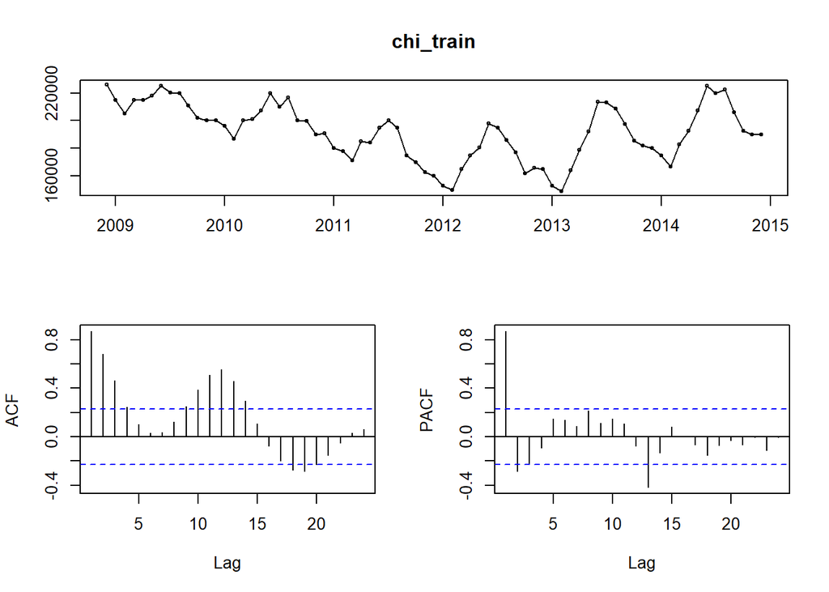

```r
#check stationarity
tsdisplay(chi_train)
```

The data looks neither stationary nor does it look to have uniform variance. Try applying BoxCox transformation to get homoscedastic data and differencing to get stationarity.

```r
BoxCox.lambda(chi_train)
```

```
## [1] 1.999924
```

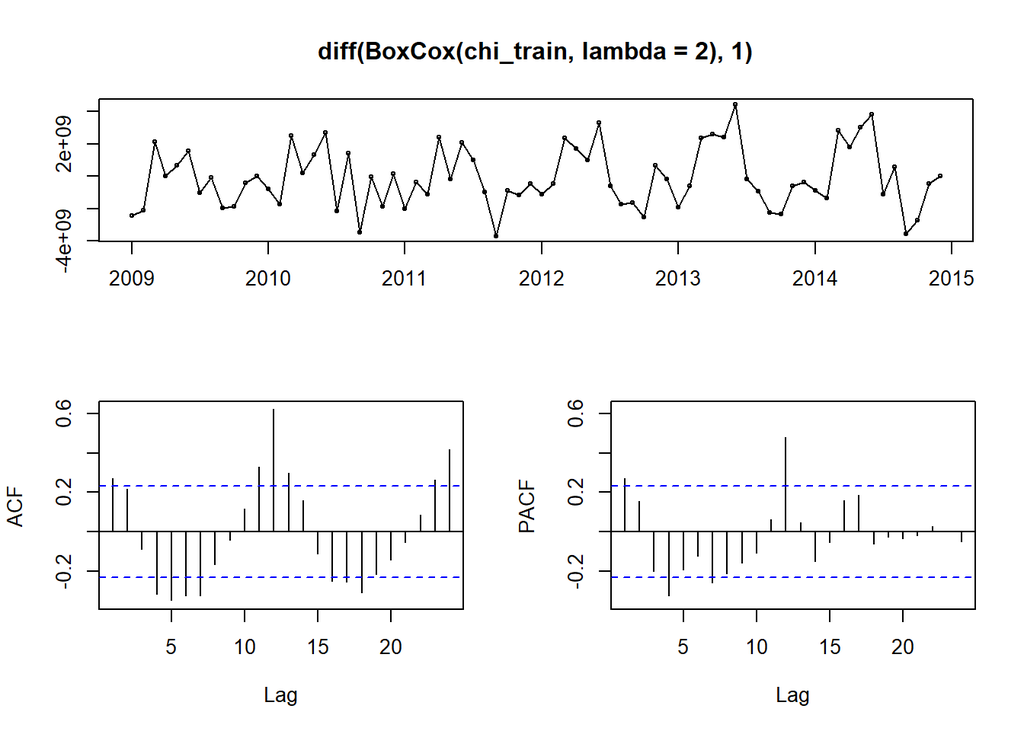

```r
tsdisplay(diff(BoxCox(chi_train,lambda=2),1))
```

```r
adf.test(diff(BoxCox(chi_train, lambda=2),1)[-1])
```

```
##
##  Augmented Dickey-Fuller Test
##
## data:  diff(BoxCox(chi_train, lambda = 2), 1)[-1]
## Dickey-Fuller = -5.7322, Lag order = 4, p-value = 0.01
## alternative hypothesis: stationary
```

```r
kpss.test(diff(BoxCox(chi_train, lambda=2),1)[-1])
```

```
##
##  KPSS Test for Level Stationarity
##
## data:  diff(BoxCox(chi_train, lambda = 2), 1)[-1]
## KPSS Level = 0.046151, Truncation lag parameter = 3, p-value = 0.1
```

P-value of 0.01 for ADF test results in rejecting the null hypothesis test and accepting the alternative hypothesis that the data is stationary. A p-value of 0.1 for the KPSS test indicates that we do not reject the null hypothesis (at 0.05 significance level) that the data is stationary. Therefore, both tests indicate that the transformed data is stationary. The variance appears to have more uniformity after applying the BoxCox transformation.

## sARIMA

### Search EACF

Check models based on EACF up to time period 3 (since it is reasonable to suspect quarterly seasonality) and limit annual seasonaliity to period 1 since we do not expect multi-year relationships. Predict next 12 months from 1/31/2015 to 12/31/2015 and check results.

```r
aic <- c()
residuals <- c()
preds <- c()
actuals <-c()

a <- eacf(diff(BoxCox(chi_train, lambda=2), 1)[-1])
```

```
## AR/MA
##   0 1 2 3 4 5 6 7 8 9 10 11 12 13
## 0 x x o x x x x o o o x  x  x  o
## 1 x x o o o o o o o o o  x  o  o
## 2 x x o o o o o o o o o  x  o  o
## 3 x x o o o o o o o o o  x  o  o
## 4 x o o o o o o o o o o  x  o  o
## 5 x o x o o o o o o o o  x  o  o
## 6 x x x o o o o o o o o  x  o  o
## 7 x o o o o o o o o o o  x  o  o
```

```r
params <- c()
ct <- 1
aic <- c()
p <- c()
q <- c()
P <- c()
Q <- c()
D <- c()
RMSE <- c()
MAE <- c()

for (y in c(0:1)) {
for (x in c(0:1)) {
for (j in c(0:3)) {
for (i in c(0:3)) {
  if ((j<=1)|(j==3 & i==0)) {}  else{

    model <-Arima(chi_train, order=c(i,1,j), lambda='auto', seasonal=list(order=c(x,1,y), period=12))
    aic[ct] <- model$aicc
    f <- forecast(model, h=12)
    residuals <- chi_test - f$mean
    RMSE[ct] <- mean(residuals**2)**0.5
    MAE[ct] <- mean(abs(residuals))
    p[ct] <- i
    q[ct] <- j
    P[ct] <- x
    Q[ct] <- y
    ct <- ct+1
  }
}}}}

res <- data.frame(aic,p,q,P,Q, RMSE, MAE)
res <- res[order(res$RMSE),]
res$RMSE_rank <- order(res$RMSE)
res <- res[order(res$aic),]
res$aic_rank <- order(res$aic)
print(res[(res$RMSE_rank<=10)&(res$aic_rank<=10),])
```

```
##         aic p q P Q     RMSE      MAE RMSE_rank aic_rank
## 15 2670.558 0 2 0 1 5400.612 3977.921         6        1
## 16 2672.936 1 2 0 1 5407.513 3985.026         7        4
## 17 2675.001 2 2 0 1 5396.150 4010.911         5        6
## 19 2675.298 1 3 0 1 5321.219 3932.472         4        8
## 18 2675.329 3 2 0 1 5179.602 3732.873         1        9
```

### View Model Candidates

Find best performance on cross validation set from 1/31/2016 to 12/31/2018 for models that don’t have significant autocorrelation amongst residuals and that are in the top 10 in RMSE during 2015 and top 10 in AICc values.

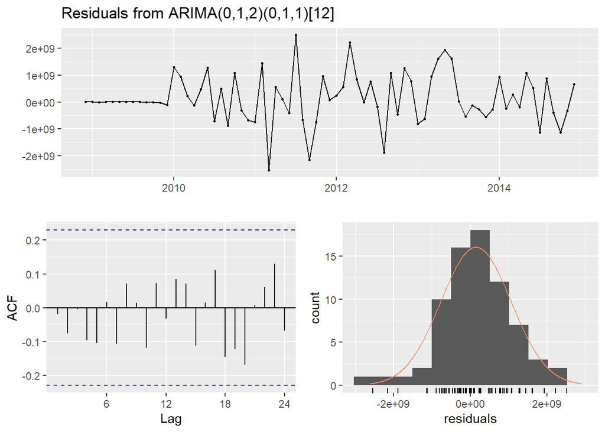

```
##
##  Ljung-Box test
##
## data:  Residuals from ARIMA(0,1,2)(0,1,1)[12]
## Q* = 7.6357, df = 12, p-value = 0.8129
##
## Model df: 3.   Total lags used: 15
```

```r
m1 <- Arima(chi_train, order=c(0,1,2),
      seasonal=list(order=c(0,1,1), period=12),
      lambda='auto', method='ML')

checkresiduals(m1)
```

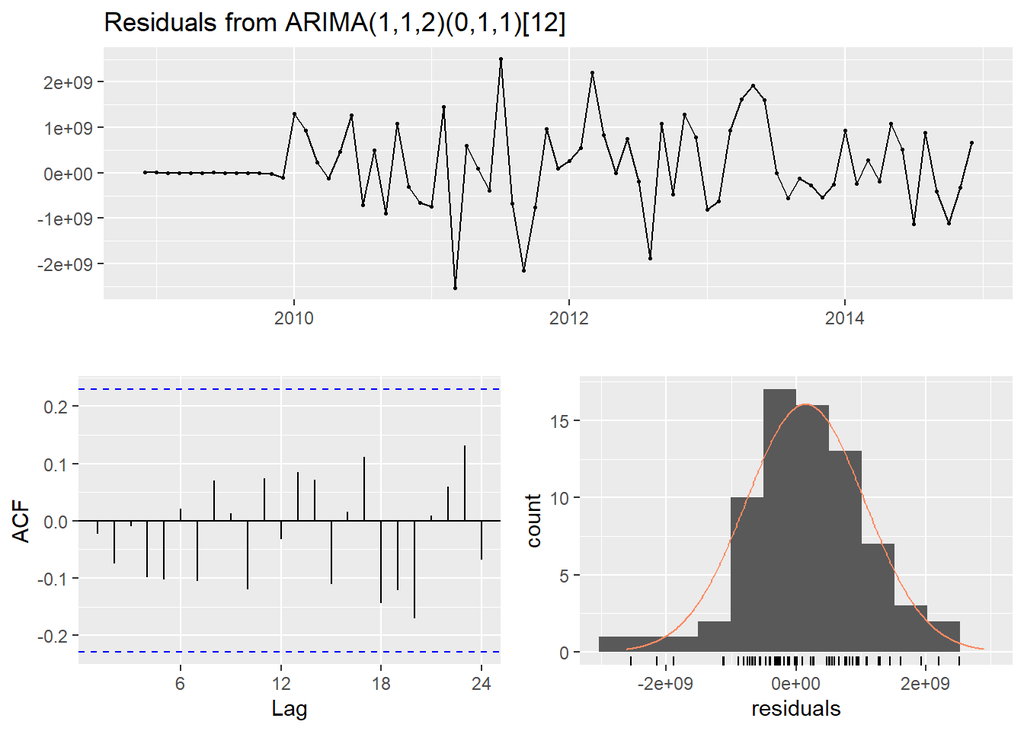

```
##
##  Ljung-Box test
##
## data:  Residuals from ARIMA(1,1,2)(0,1,1)[12]
## Q* = 7.6243, df = 11, p-value = 0.7465
##
## Model df: 4.   Total lags used: 15
```

```r
m2 <- Arima(chi_train, order=c(1,1,2),
      seasonal=list(order=c(0,1,1), period=12),
      lambda='auto', method='ML')

checkresiduals(m2)
```

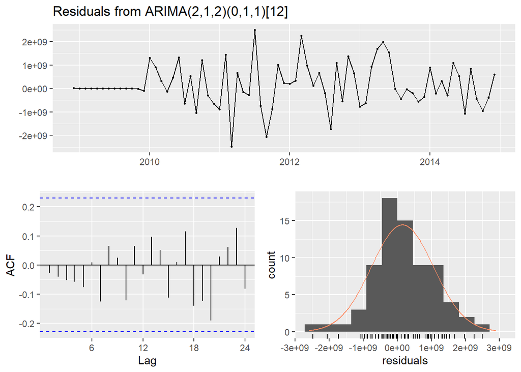

```
##
##  Ljung-Box test
##
## data:  Residuals from ARIMA(2,1,2)(0,1,1)[12]
## Q* = 6.8935, df = 10, p-value = 0.7355
##
## Model df: 5.   Total lags used: 15
```

```r
m3 <- Arima(chi_train, order=c(2,1,2),
      seasonal=list(order=c(0,1,1), period=12),
      lambda='auto', method='ML')

checkresiduals(m3)
```

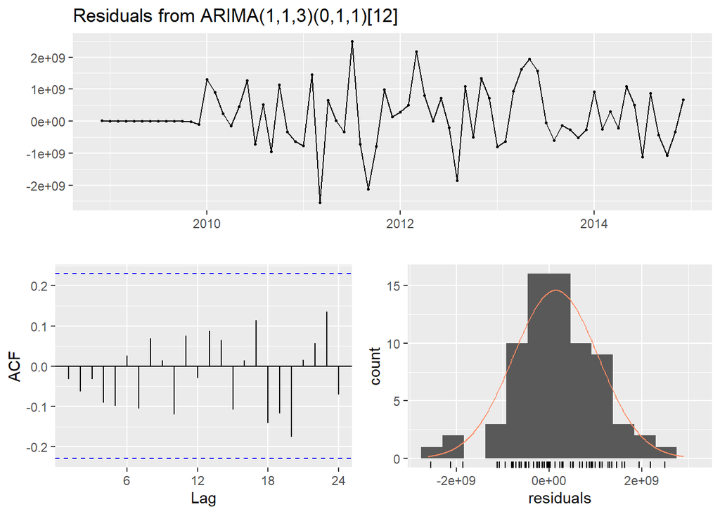

```
##
##  Ljung-Box test
##
## data:  Residuals from ARIMA(1,1,3)(0,1,1)[12]
## Q* = 7.3231, df = 10, p-value = 0.6946
##
## Model df: 5.   Total lags used: 15
```

```r
m4 <- Arima(chi_train, order=c(1,1,3),
      seasonal=list(order=c(0,1,1), period=12),
      lambda='auto', method='ML')

checkresiduals(m4)
```

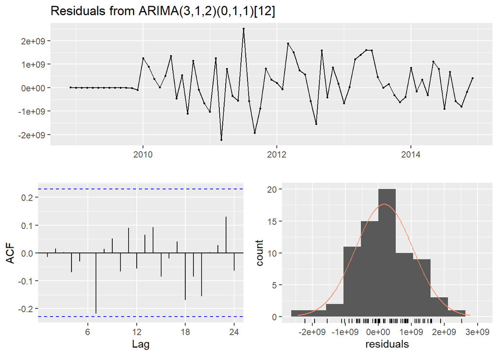

```
##
##  Ljung-Box test
##
## data:  Residuals from ARIMA(3,1,2)(0,1,1)[12]
## Q* = 7.9862, df = 9, p-value = 0.5355
##
## Model df: 6.   Total lags used: 15
```

```r
m5 <- Arima(chi_train, order=c(3,1,2),
      seasonal=list(order=c(0,1,1), period=12),
      lambda='auto', method='ML')

checkresiduals(m5)
```

All of the models fail to reject the null hypothesis of the Ljung-Box test, indicating the residuals do not exhibit significant autocorrelation. Therefore, test all identified models on cross validation data.

## Cross Validation Results

```r
k <- 72 # minimum observations (6 years)
p <- 12 # Period

st <- 2014+11/12
```

### ARIMA(0,1,2)(0,1,1)[12]

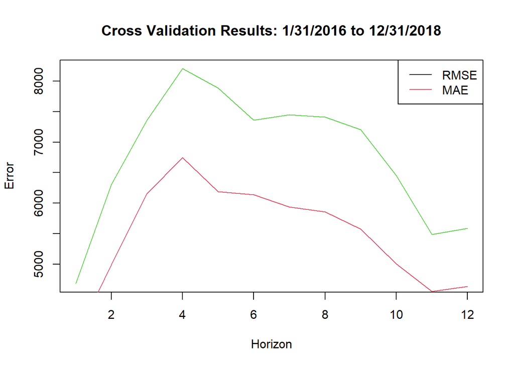

```r
error <- matrix(NA,36, 12)
dates <- c()

for(i in (1:36))

{
  train <- window(chi_median, start=st+(i-k+1)/p, end=st+i/p)
  test <- window(chi_median, start=st + (i+1)/p, end=st+(i+12)/p)
  dates[i] <- st+(i+12)/p
  model <-  Arima(train, order=c(0,1,2),
                  seasonal=list(order=c(0,1,1), period=p),
                  lambda='auto', method='ML')

  f <- forecast(model, h=12)
  error[i,1:length(test)] <- f[['mean']]-test
}

MAE <- colMeans(abs(error), na.rm=TRUE)
RMSE <- sqrt(colMeans(error**2, na.rm=TRUE))

plot(1:12, RMSE, type="l",col=3,xlab="Horizon", ylab="Error",
     main='Cross Validation Results: 1/31/2016 to 12/31/2018')
lines(1:12, MAE, type="l",col=2)
legend("topright",legend=c("RMSE", "MAE"),col=1:4,lty=1)
```

```r
print(MAE)
```

```
##  [1] 3803.541 4997.631 6159.680 6749.026 6191.357 6143.212 5940.168 5856.475
##  [9] 5574.754 5007.340 4558.790 4640.139
```

```r
print(RMSE)
```

```
##  [1] 4688.285 6309.634 7361.954 8201.461 7883.278 7358.686 7449.692 7408.214
##  [9] 7200.691 6450.049 5492.715 5587.209
```

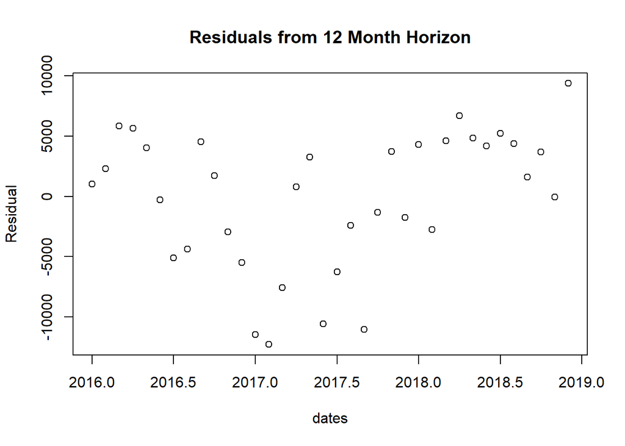

```r
plot(dates, error[,12], ylab='Residual', main='Residuals from 12 Month Horizon')
```

### ARIMA(1,1,2)(0,1,1)[12]

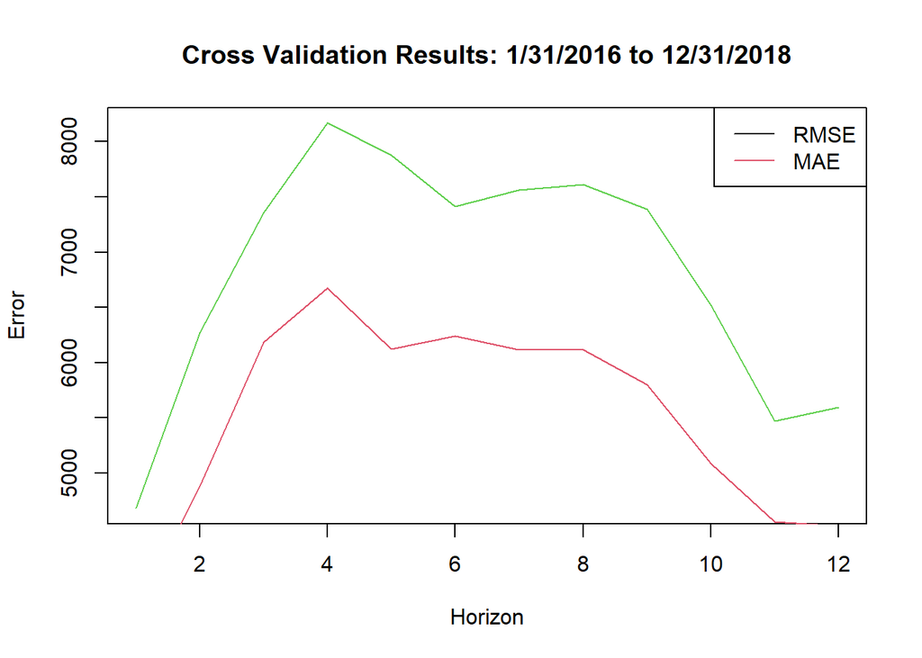

```r
error <- matrix(NA,36, 12)
dates <- c()

for(i in (1:36))

{
  train <- window(chi_median, start=st+(i-k+1)/p, end=st+i/p)
  test <- window(chi_median, start=st + (i+1)/p, end=st+(i+12)/p)
  dates[i] <- st+(i+12)/p
  model <-  Arima(train, order=c(1,1,2),
                  seasonal=list(order=c(0,1,1), period=p),
                  lambda='auto', method='ML')

  f <- forecast(model, h=12)
  error[i,1:length(test)] <- f[['mean']]-test
}

MAE <- colMeans(abs(error), na.rm=TRUE)
RMSE <- sqrt(colMeans(error**2, na.rm=TRUE))

plot(1:12, RMSE, type="l",col=3,xlab="Horizon", ylab="Error",
     main='Cross Validation Results: 1/31/2016 to 12/31/2018')
lines(1:12, MAE, type="l",col=2)
legend("topright",legend=c("RMSE", "MAE"),col=1:4,lty=1)
```

```r
print(MAE)
```

```
##  [1] 3743.000 4882.963 6182.744 6672.910 6122.133 6243.337 6118.230 6114.807
##  [9] 5799.082 5084.404 4558.313 4520.344
```

```r
print(RMSE)
```

```
##  [1] 4683.235 6269.323 7356.553 8166.302 7879.004 7413.672 7562.310 7611.250
##  [9] 7389.057 6517.319 5473.160 5594.454
```

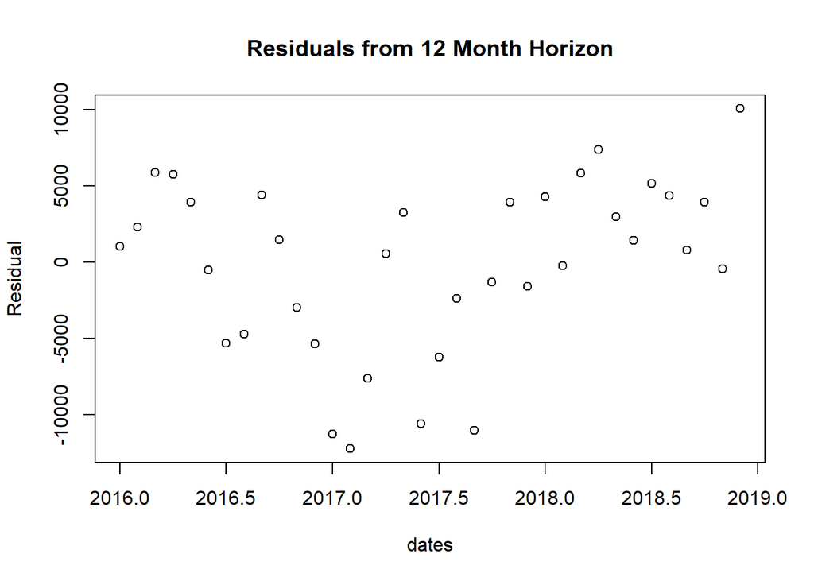

```r
plot(dates, error[,12], ylab='Residual', main='Residuals from 12 Month Horizon')
```

### ARIMA(2,1,2)(0,1,1)[12]

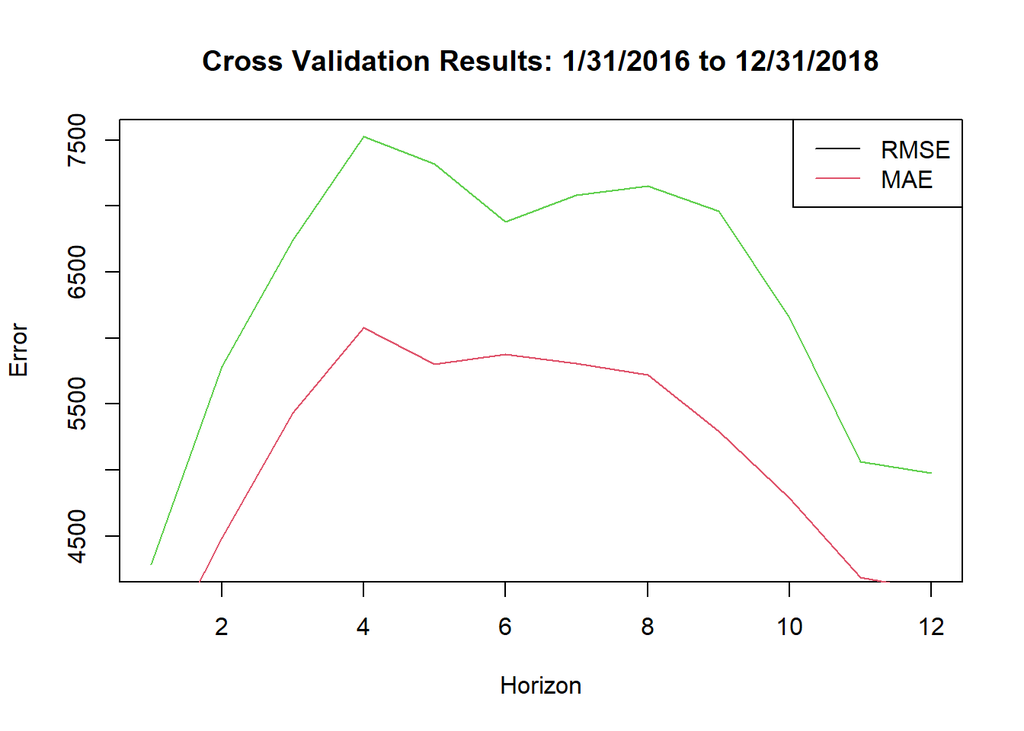

```r
error <- matrix(NA,36, 12)
dates <- c()

for(i in (1:36))

{
  train <- window(chi_median, start=st+(i-k+1)/p, end=st+i/p)
  test <- window(chi_median, start=st + (i+1)/p, end=st+(i+12)/p)
  dates[i] <- st+(i+12)/p
  model <-  Arima(train, order=c(2,1,2),
                  seasonal=list(order=c(0,1,1), period=p),
                  lambda='auto', method='ML')

  f <- forecast(model, h=12)
  error[i,1:length(test)] <- f[['mean']]-test
}

MAE <- colMeans(abs(error), na.rm=TRUE)
RMSE <- sqrt(colMeans(error**2, na.rm=TRUE))

plot(1:12, RMSE, type="l",col=3,xlab="Horizon", ylab="Error",
     main='Cross Validation Results: 1/31/2016 to 12/31/2018')
lines(1:12, MAE, type="l",col=2)
legend("topright",legend=c("RMSE", "MAE"),col=1:4,lty=1)
```

```r
print(MAE)
```

```
##  [1] 3438.702 4486.533 5434.527 6077.933 5803.464 5878.507 5808.077 5721.227
##  [9] 5296.547 4787.479 4189.205 4085.994
```

```r
print(RMSE)
```

```
##  [1] 4283.791 5783.458 6742.055 7525.176 7321.597 6883.154 7082.587 7152.825
##  [9] 6963.139 6156.445 5061.747 4975.035
```

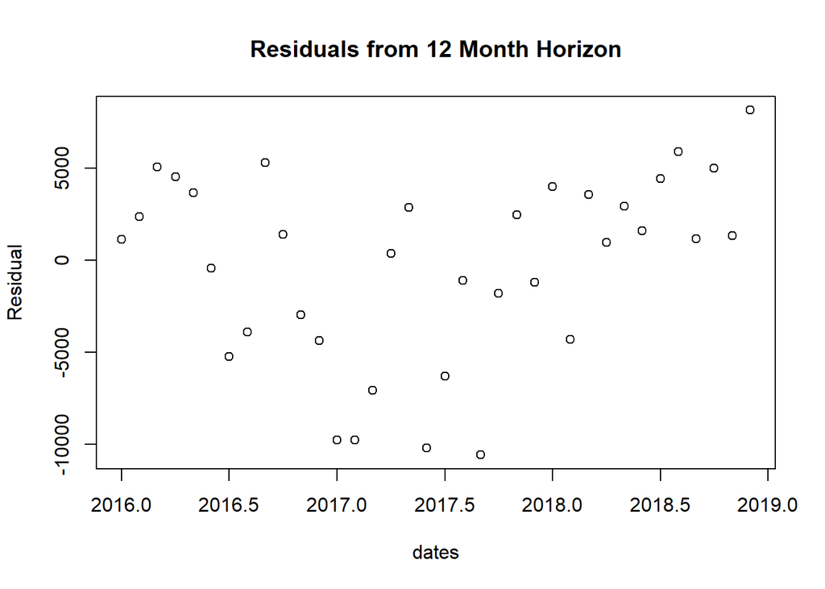

```r
plot(dates, error[,12], ylab='Residual', main='Residuals from 12 Month Horizon')
```

### ARIMA(1,1,3)(0,1,1)[12]

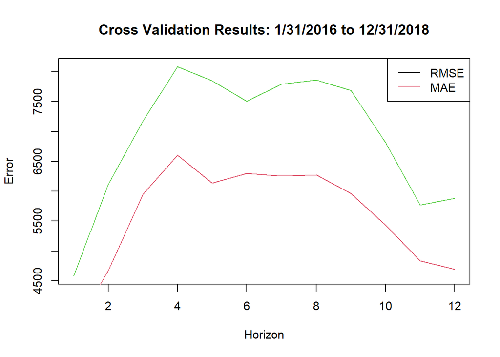

```r
error <- matrix(NA,36, 12)
dates <- c()

for(i in (1:36))

{
  train <- window(chi_median, start=st+(i-k+1)/p, end=st+i/p)
  test <- window(chi_median, start=st + (i+1)/p, end=st+(i+12)/p)
  dates[i] <- st+(i+12)/p
  model <-  Arima(train, order=c(1,1,3),
                  seasonal=list(order=c(0,1,1), period=p),
                  lambda='auto', method='ML')

  f <- forecast(model, h=12)
  error[i,1:length(test)] <- f[['mean']]-test
}

MAE <- colMeans(abs(error), na.rm=TRUE)
RMSE <- sqrt(colMeans(error**2, na.rm=TRUE))

plot(1:12, RMSE, type="l",col=3,xlab="Horizon", ylab="Error",
     main = 'Cross Validation Results: 1/31/2016 to 12/31/2018' )
lines(1:12, MAE, type="l",col=2)
legend("topright",legend=c("RMSE", "MAE"),col=1:4,lty=1)
```

```r
print(MAE)
```

```
##  [1] 3685.764 4674.775 5947.841 6607.396 6137.613 6301.777 6256.876 6275.198
##  [9] 5960.453 5436.808 4834.993 4694.453
```

```r
print(RMSE)
```

```
##  [1] 4586.179 6117.457 7174.752 8084.033 7849.487 7508.708 7791.150 7862.984
##  [9] 7690.538 6817.756 5771.834 5881.870
```

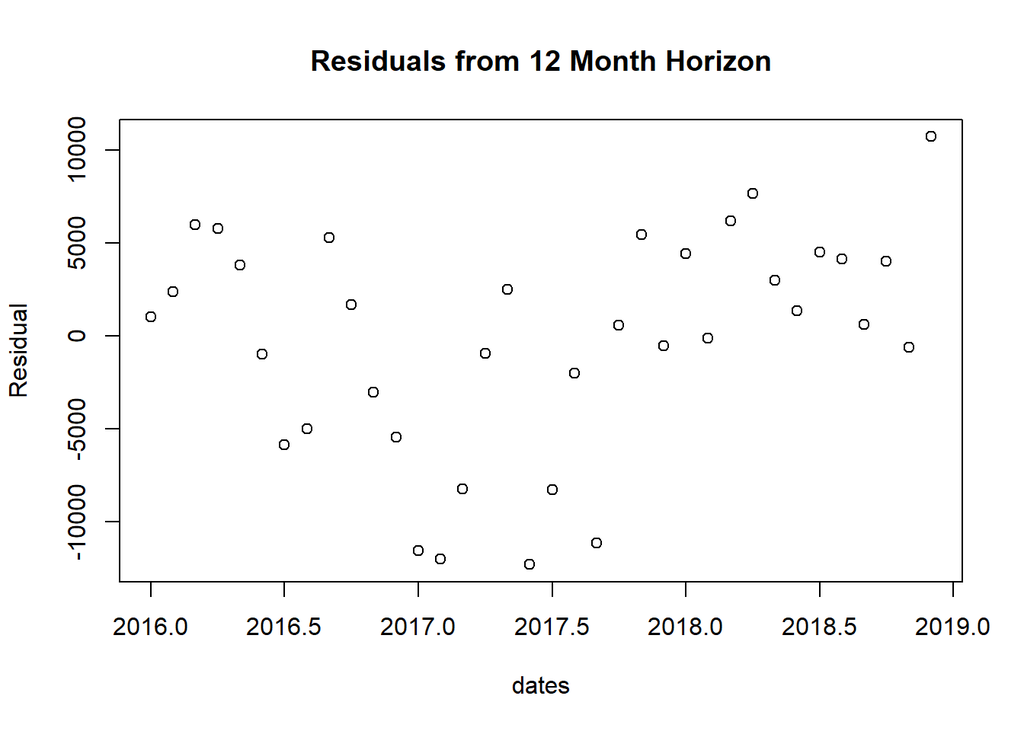

```r
plot(dates, error[,12], ylab='Residual', main='Residuals from 12 Month Horizon')
```

### ARIMA(3,1,2)(0,1,1)[12]

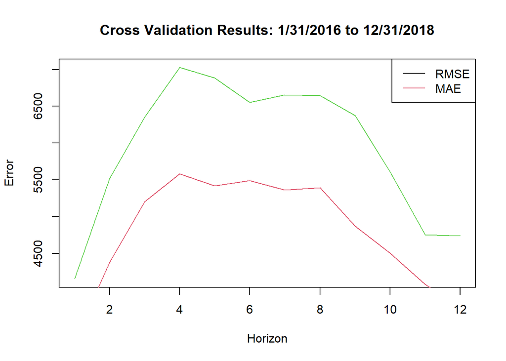

```r
error <- matrix(NA,36, 12)
dates <- c()

for(i in (1:36))

{
  train <- window(chi_median, start=st+(i-k+1)/p, end=st+i/p)
  test <- window(chi_median, start=st + (i+1)/p, end=st+(i+12)/p)
  dates[i] <- st+(i+12)/p
  model <-  Arima(train, order=c(3,1,2),
                  seasonal=list(order=c(0,1,1), period=p),
                  lambda='auto', method='ML')

  f <- forecast(model, h=12)
  error[i,1:length(test)] <- f[['mean']]-test
}

MAE <- colMeans(abs(error), na.rm=TRUE)
RMSE <- sqrt(colMeans(error**2, na.rm=TRUE))

plot(1:12, RMSE, type="l",col=3,xlab="Horizon", ylab="Error", main='Cross Validation Results: 1/31/2016 to 12/31/2018')
lines(1:12, MAE, type="l",col=2)
legend("topright",legend=c("RMSE", "MAE"),col=1:4,lty=1)
```

```r
print(MAE)
```

```
##  [1] 3319.642 4379.453 5205.517 5581.377 5416.905 5492.434 5364.788 5395.785
##  [9] 4874.428 4505.855 4079.990 3766.019
```

```r
print(RMSE)
```

```
##  [1] 4155.545 5519.241 6356.268 7026.657 6885.233 6552.000 6653.208 6643.738
##  [9] 6374.559 5607.051 4754.144 4740.121
```

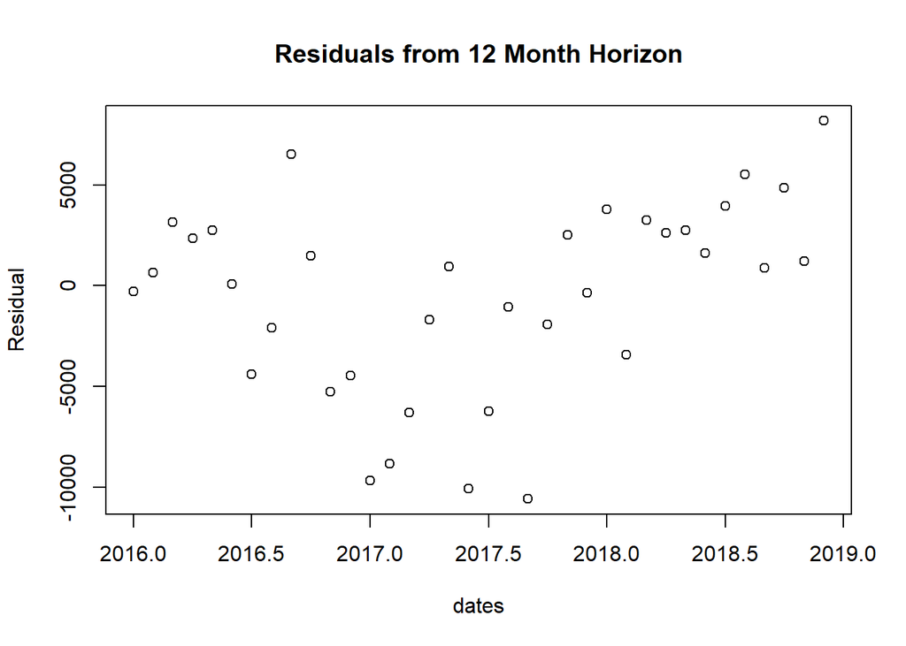

```r
plot(dates, error[,12], ylab='Residual', main='Residuals from 12 Month Horizon')
```

The ARIMA(3,1,2)(0,1,1)[12] model performed the best on both a MAE and RMSE basis. We select this model as our best sARIMA model and will view results on during the test period, 1/31/2019 to 12/31/2019 (we exclude 2020 to remove the impact of Covid).

## Test Set Results

### ARIMA(3,1,2)(0,1,1)[12]

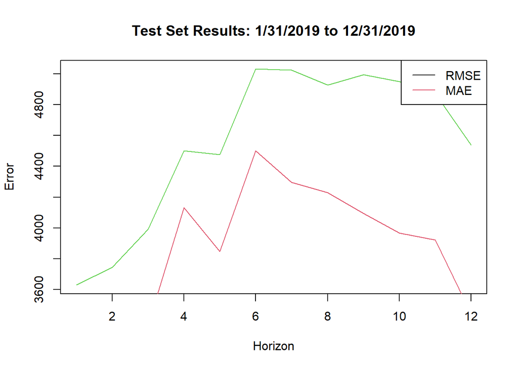

```r
error <- matrix(NA,12, 12)
dates <- c()

for(i in (37:48))

{
  train <- window(chi_median, start=st+(i-k+1)/p, end=st+i/p)
  test <- window(chi_median, start=st + (i+1)/p, end=st+(i+12)/p)
  dates[i-36] <- st+(i+12)/p
  model <-  Arima(train, order=c(3,1,2),
                  seasonal=list(order=c(0,1,1), period=p),
                  lambda='auto', method='ML')

  f <- forecast(model, h=12)
  error[i-36,1:length(test)] <- f[['mean']]-test
}

MAE <- colMeans(abs(error), na.rm=TRUE)
RMSE <- sqrt(colMeans(error**2, na.rm=TRUE))

plot(1:12, RMSE, type="l",col=3,xlab="Horizon", ylab="Error",
     main='Test Set Results: 1/31/2019 to 12/31/2019')
lines(1:12, MAE, type="l",col=2)
legend("topright",legend=c("RMSE", "MAE"),col=1:4,lty=1)
```

```r
print(MAE)
```

```
##  [1] 2938.774 2954.838 3372.147 4131.359 3848.351 4500.228 4296.495 4228.516
##  [9] 4094.856 3968.118 3921.513 3444.865
```

```r
print(RMSE)
```

```
##  [1] 3630.183 3745.419 3993.453 4501.558 4475.265 5031.054 5024.223 4928.334
##  [9] 4993.494 4950.097 4873.513 4538.606
```

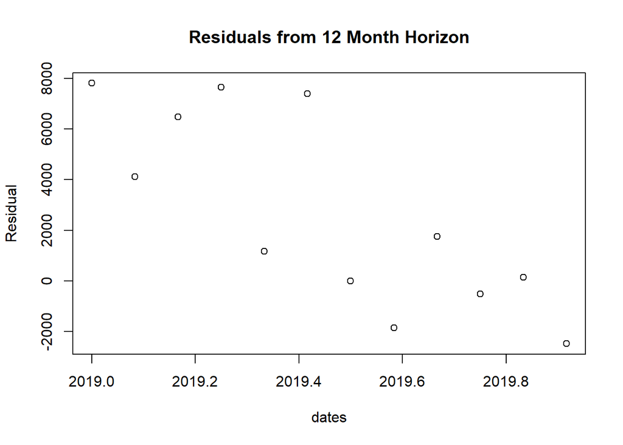

```r
plot(dates, error[,12], ylab='Residual', main='Residuals from 12 Month Horizon')
```

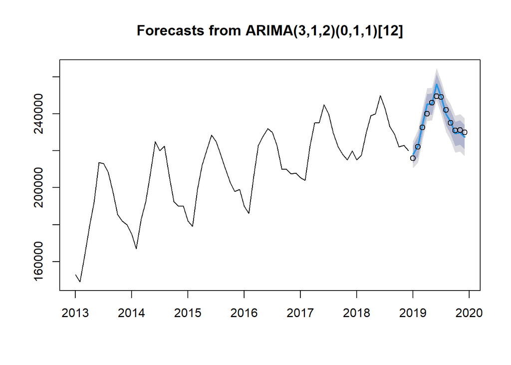

```r
plot(f)
points(test)
```

The model continues to perform well on the test set, both RMSE and MAE are very reasonable relative to the values of median home prices in Chicago. This is a strong candidate for best our model.